| National Park Service U.S. Department of the Interior Natural Resource Stewardship and Science |  |
| --- | --- |

# Evaluation of Custom AOAs for National Park Service Units for use in the National Park Environmental Settings Monitoring Protocol. 2018.

Data Release Report NPS/NRSS/DRR—2020/1

Michelle Kinseth

Managed Business Solutions (MBS), a Sealaska Company  
Contractor to National Park Service  
Natural Resource Stewardship and Science

Lisa Nelson

NPS Inventory & Monitoring Division  
1201 Oakridge, Suite 150  
Fort Collins, Colorado

04 April, 2020

Abstract

This data report (and associated datasets) documents the acquisition and preparation of National Park Service (NPS) custom areas of analysis (AOAs) for use within the Inventory and Monitoring Program (I&M). AOA datasets were updated through September 30, 2018 and supersede all previous releases/versions.  
The Inventory and Monitoring Division (IMD), under the I&M Program, works with a select subset of the more than 400 park units of the National Park System; NPS parks that are part of the I&M Program are included in this subset. Landscape dynamics, weather, and stream hydrology measures are monitored using methods outlined in the National Park Environmental Settings Monitoring Protocol (DeVivo et.al 2018), which includes areas inside and near parks with significant natural resources. Annually, AOAs are updated or created based on custom requests. AOA datasets documented in this report and may not include all NPS units, or other NPS areas. These AOAs are not official boundaries and are not intended for use outside NPS Inventory and Monitoring..

# 1 Background and Summary

The status and condition of park resources is affected by interconnected system drivers at regional to global scales surrounding parks. Landscape dynamics provide an important context for understanding patterns and changes in resources monitored at parks. The National Park Environmental Settings Monitoring Protocol produces nationally-standardized status and trend information related to *Landscape Dynamics, Climate, and Surface Water Dynamics* metrics (DeVivo et al. 2018).

Annually, IMD calculates protocol metrics for areas of analysis (AOAs). AOAs are defined geographic extents of interest. Custom AOAs include any area of interest to a park or network. Only AOAs submitted by I&M Program parks or networks are included in the custom AOA dataset. Not all NPS units are represented in the custom AOA dataset.

# 2 Methods

The creation of custom AOAs takes place annually. Custom AOAs are derived from and utilize custom polygons submitted by parks or networks. Custom AOAs (NPS IMD 2018) are used in support of the National Park Environmental Settings Monitoring Protocol (DeVivo et al. 2018). This report documents the incorporation of new and/or updated custom AOAs submitted by a park or network (Figure 1) from September 30, 2017 through September 30, 2018 (NPS IMD 2018b). In that time period, two custom AOAs were submitted for inclusion in the dataset (see Tables 1 and 7 below).

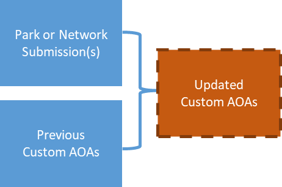

**Figure 1**. General process flow for custom landscape dynamics AOAs. Orange items indicate datasets generated with this report. Dash-outlined items may or may not be generated annually; there may or may not be custom AOAs submitted each year.

## 2.1 Source Data

### 2.1.1 Network Submission(s)

The Mediterranean Network (MEDN) submitted new custom AOAs. Custom AOA updates due to network submissions are summarized in Table 1.

**Table 1**: All new and/or updated custom AOAs submitted for use. AOA Type is defined by the submitting Network.

[output not shown]

### 2.1.2 Previous Custom AOA Dataset

Unless otherwise notified by the respective park or network, all submitted custom AOAs will be used indefinitely (NPS IMD 2018a), and any new and/or updated submissions are merged with the preceding dataset.

## 2.2 Create Custom AOAs

New and/or updated network-submitted polygons were combined into one collective dataset and additional attribute fields and domains managed by IMD staff were added. See Appendix C for the required script to create the published custom AOA output.

### 2.2.1 Documenting Change in Custom AOAs

The attribute “change reason from preceding version” for custom AOAs indicates why a custom AOA boundary change occurred (Tables 2 and 3). After creating custom AOAs, all new and/or changed custom AOAs were identified based on the following criteria: (1) a previously unused custom AOA was identified and incorporated into the dataset; (2) a previously used custom AOA was changed by the Network and the updated version supersedes the preceding version; (3) a previously used custom AOA is no longer in use and was removed (inactivated) from the dataset; (4) a previously used custom AOA does not meet any of the above criteria, there was no change. See Appendix B for a full list of all added, changed, or removed custom AOAs (Table 7).

**Table 2.** Criteria for identifying changes in custom AOAs and the associated change reason from preceding version label and definition.

| **Criteria** | **Change Reason from Preceding Version** **Label** | **Change Reason from Preceding Version** **Definition** |
| --- | --- | --- |
| Custom AOA was previously not included in the custom AOA dataset; it was added for use. | Added feature | Addition of previously unused feature |
| Custom AOA has been changed by the Network; the updated version supersedes the preceding version | Update | Update to dynamically edited data where there are no released versions |
| Custom AOA is no longer included in the custom AOA dataset, it was removed from use. | Removed feature | Removal of feature used in preceding version |
| Custom AOA does not meet other criteria, the custom AOA has not changed from preceding version | No change | No change |

Change reason applies only to the current version of custom AOAs (NPS IMD 2018b) when compared to the preceding version of custom AOAs (NPS IMD 2017).

**Table 3.** Count of change reason from preceding version for the custom AOAs dataset.

| Network | Added feature (A) | Update (U) | Removed feature (RM) | No change (NC) | Total |
| --- | --- | --- | --- | --- | --- |
| Cumberland Piedmont Network (CUPN) | 0 | 0 | 0 | 42 | 42 |
| Eastern Rivers and Mountains (ERMN) | 0 | 0 | 0 | 78 | 78 |
| Great Lakes Network (GLKN) | 0 | 0 | 0 | 9 | 9 |
| Greater Yellowstone Network (GRYN) | 0 | 0 | 0 | 6 | 6 |
| Heartland Network (HTLN) | 0 | 0 | 0 | 26 | 26 |
| Klamath Network (KLMN) | 0 | 0 | 0 | 7 | 7 |
| Mediterranean Coast Network (MEDN) | 2 | 0 | 0 | 0 | 2 |
| Mojave Desert Network (MOJN) | 0 | 0 | 0 | 1 | 1 |
| North Coast and Cascades Network (NCCN) | 0 | 0 | 0 | 13 | 13 |
| National Capital Region Network (NCRN) | 0 | 0 | 0 | 4 | 4 |
| Northeast Temperate Network (NETN) | 0 | 0 | 0 | 67 | 67 |
| Pacific Islands Network (PACN) | 0 | 0 | 0 | 9 | 9 |
| Rocky Mountain Network (ROMN) | 0 | 0 | 0 | 364 | 364 |
| Southeast Coast Network (SECN) | 0 | 0 | 0 | 85 | 85 |
| South Florida/Caribbean Network (SFCN) | 0 | 0 | 0 | 4 | 4 |
| Combined (All Networks) | 2 | 0 | 0 | 715 | 717 |

Feature addition, removal, or replacement is summed for the source datasets (Table 4). Two new custom AOAs were submitted. Only active features from the sources are used subsequently. In the source custom polygon dataset, features removed or replaced because of changes are assigned a lifecycle status of ‘inactive’. Also included in the custom AOAs output database is a combined feature class of all custom AOAs across all networks.

**Table 4.** Summary of count of all areas of analysis (AOAs) changed, added, or removed from the custom AOAs dataset.

|  | Count of Custom AOAs |
| --- | --- |
| Total Features in Preceding Custom AOAs | 715 |
| **Features Changed** | 0 |
| **Features Added** | 2 |
| **Features Removed** | 0 |
| **Total Features in Updated Custom AOAs** | **717** |

### 2.2.2 Inactivation of Obsolete Custom AOAs

If a previously existing custom AOA feature was updated or removed, it was assigned a status of ‘inactive’ (Table 5). No features were flagged as inactive for the time period documented in this report.

**Table 5.** Active and inactive feature counts for the custom AOAs dataset, by Network.

| Network | Active | Inactive | Total Features |
| --- | --- | --- | --- |
| Cumberland Piedmont Network (CUPN) | 42 | 0 | 42 |
| Eastern Rivers and Mountains (ERMN) | 78 | 0 | 78 |
| Great Lakes Network (GLKN) | 9 | 0 | 9 |
| Greater Yellowstone Network (GRYN) | 6 | 0 | 6 |
| Heartland Network (HTLN) | 26 | 0 | 26 |
| Klamath Network (KLMN) | 7 | 0 | 7 |
| Mediterranean Coast Network (MEDN) | 2 | 0 | 2 |
| Mojave Desert Network (MOJN) | 1 | 0 | 1 |
| North Coast and Cascades Network (NCCN) | 13 | 0 | 13 |
| National Capital Region Network (NCRN) | 4 | 0 | 4 |
| Northeast Temperate Network (NETN) | 67 | 0 | 67 |
| Pacific Islands Network (PACN) | 9 | 0 | 9 |
| Rocky Mountain Network (ROMN) | 364 | 0 | 364 |
| Southeast Coast Network (SECN) | 85 | 0 | 85 |
| South Florida/Caribbean Network (SFCN) | 4 | 0 | 4 |
| Combined (All Networks) | 717 | 0 | 717 |

## 2.3 Code availability

See Appendices C and D for the python script and technical requirements needed to execute these methods.

# 3 Data Records

One dataset was generated as a part of this effort (Table 6):

1. **Landscape Dynamics Custom AOAs (IMD_BND_ESProtocol_Custom_AOA.gdb)**. This file geodatabase contains geographically distinct feature classes for each I&M Program network that submitted custom polygons (Available at https://irma.nps.gov/DataStore/Reference/Profile/2266898). Feature classes include:
   1. *Cumberland Piedmont Network* (CUPN_AOA_MACA_KGWB_Basins_Edited), a polygon feature class representing 39 AOAs for CUPN. This feature class is spatially projected to USA Contiguous Albers Equal Area Conic USGS (WKID 102039).
   2. *Cumberland Piedmont Network* (CUPN_AOA_MACA_Major_Surface_Basins), a polygon feature class representing three AOAs for CUPN. This feature class is spatially projected to USA Contiguous Albers Equal Area Conic USGS (WKID 102039).
   3. *Eastern Rivers and Mountains Network* (ERMN_BMI_Watersheds_AOA), a polygon feature class representing 78 AOAs for ERMN. This feature class is spatially projected to USA Contiguous Albers Equal Area Conic USGS (WKID 102039).
   4. *Great Lakes Network* (GLKN_Areas), a polygon feature class representing nine AOAs for GLKN. This feature class is spatially projected to USA Contiguous Albers Equal Area Conic USGS (WKID 102039).
   5. *Greater Yellowstone Network* (GRYN_Areas), a polygon feature class representing six AOAs for GRYN. This feature class is spatially projected to USA Contiguous Albers Equal Area Conic USGS (WKID 102039).
   6. *Heartland Network* (HTLN_BirdConservationUnits), a polygon feature class representing nine AOAs for HTLN. This feature class is spatially projected to USA Contiguous Albers Equal Area Conic USGS (WKID 102039).
   7. *Heartland Network* (HTLN_HUC8Watersheds), a polygon feature class representing 17 AOAs for HTLN. This feature class is spatially projected to USA Contiguous Albers Equal Area Conic USGS (WKID 102039).
   8. *Klamath Network* (KLMN_PM), a polygon feature class representing seven AOAs for KLMN. This feature class is spatially projected to USA Contiguous Albers Equal Area Conic USGS (WKID 102039).
   9. *Mediterranean Coast Network* (MEDN_Areas), a polygon feature class representing two AOAs for MEDN. This feature class is spatially projected to USA Contiguous Albers Equal Area Conic USGS (WKID 102039).
   10. *Mojave Desert Network* (MOJN_Habitat), a polygon feature class representing one AOA for MOJN. This feature class is spatially projected to USA Contiguous Albers Equal Area Conic USGS (WKID 102039).
   11. *North Coast and Cascades Network* (NCCN_AOA_LPa01), a polygon feature class representing seven AOAs for NCCN. This feature class is spatially projected to USA Contiguous Albers Equal Area Conic USGS (WKID 102039).
   12. *North Coast and Cascades Network* (NCCN_AOA_PACE), a polygon feature class representing three AOAs for NCCN. This feature class is spatially projected to USA Contiguous Albers Equal Area Conic USGS (WKID 102039).
   13. *North Coast and Cascades Network* (NCCN_AOA_Protected_Areas), a polygon feature class representing three AOAs for NCCN. This feature class is spatially projected to USA Contiguous Albers Equal Area Conic USGS (WKID 102039).
   14. *National Capital Region Network* (NCRN_Custom_AOAs), a polygon feature class representing four AOAs for NCRN. This feature class is spatially projected to USA Contiguous Albers Equal Area Conic USGS (WKID 102039).
   15. *Northeast Temperate Network* (NETN_AOA_HUC10_Shell), a polygon feature class representing one AOA for NETN. This feature class is spatially projected to USA Contiguous Albers Equal Area Conic USGS (WKID 102039).
   16. *Northeast Temperate Network* (NETN_AOA_SubSections), a polygon feature class representing 50 AOAs for NETN. This feature class is spatially projected to USA Contiguous Albers Equal Area Conic USGS (WKID 102039).
   17. *Northeast Temperate Network* (NETN_KAWW_HUC10), a polygon feature class representing nine AOAs for NETN. This feature class is spatially projected to USA Contiguous Albers Equal Area Conic USGS (WKID 102039).
   18. *Northeast Temperate Network* (NETN_KAWW_HUC10_Shell), a polygon feature class representing one AOA for NETN. This feature class is spatially projected to USA Contiguous Albers Equal Area Conic USGS (WKID 102039).
   19. *Northeast Temperate Network* (NETN_KAWW_SubSections), a polygon feature class representing six AOAs for NETN. This feature class is spatially projected to USA Contiguous Albers Equal Area Conic USGS (WKID 102039).
   20. *Pacific Islands Network* (PACN_Guam_Islands), a polygon feature class representing one AOA for PACN. This feature class is spatially projected to UTM Zone 55N (WKID 32655).
   21. *Pacific Islands Network* (PACN_Hawaii_Islands), a polygon feature class representing four AOAs for PACN. This feature class is spatially projected to UTM Zone 5N (WKID 26905).
   22. *Pacific Islands Network* (PACN_Saipan_Islands), a polygon feature class representing one AOAs for PACN. This feature class is spatially projected to UTM Zone 55N (WKID 32655).
   23. *Pacific Islands Network* (PACN_Samoa_Islands), a polygon feature class representing three AOAs for PACN. This feature class is spatially projected to UTM Harn Zone 2S (WKID 2195).
   24. *Rocky Mountain Network* (ROMN_Crown_Major_AOAs), a polygon feature class representing two AOAs for ROMN. This feature class is spatially projected to USA Contiguous Albers Equal Area Conic USGS (WKID 102039).
   25. *Rocky Mountain Network* (ROMN_Crown_ManagementAreas), a polygon feature class representing five AOAs for ROMN. This feature class is spatially projected to USA Contiguous Albers Equal Area Conic USGS (WKID 102039).
   26. *Rocky Mountain Network* (ROMN_Crown_Watersheds), a polygon feature class representing six AOAs for ROMN. This feature class is spatially projected to USA Contiguous Albers Equal Area Conic USGS (WKID 102039).
   27. *Rocky Mountain Network* (ROMN_FLFO), a polygon feature class representing 12 AOAs for ROMN. This feature class is spatially projected to USA Contiguous Albers Equal Area Conic USGS (WKID 102039).
   28. *Rocky Mountain Network* (ROMN_ROMO), a polygon feature class representing one AOA for ROMN. This feature class is spatially projected to USA Contiguous Albers Equal Area Conic USGS (WKID 102039).
   29. *Rocky Mountain Network* (ROMN_SEI_GLAC), a polygon feature class representing 50 AOAs for ROMN. This feature class is spatially projected to USA Contiguous Albers Equal Area Conic USGS (WKID 102039).
   30. *Rocky Mountain Network* (ROMN_SEI_ROMO), a polygon feature class representing 51 AOAs for ROMN. This feature class is spatially projected to USA Contiguous Albers Equal Area Conic USGS (WKID 102039).
   31. *Rocky Mountain Network* (ROMN_WEI_GRSA), a polygon feature class representing 83 AOAs for ROMN. This feature class is spatially projected to USA Contiguous Albers Equal Area Conic USGS (WKID 102039).
   32. *Rocky Mountain Network* (ROMN_WEI_ROMO), a polygon feature class representing 154 AOAs for ROMN. This feature class is spatially projected to USA Contiguous Albers Equal Area Conic USGS (WKID 102039).
   33. *Southeast Coast Network* (SECN_Watersheds), a polygon feature class representing 85 AOAs for SECN. This feature class is spatially projected to USA Contiguous Albers Equal Area Conic USGS (WKID 102039).
   34. *South Florida/Caribbean Network* (SFCN_Florida_Areas), a polygon feature class representing two AOAs for SFCN. This feature class is spatially projected to USA Contiguous Albers Equal Area Conic USGS (WKID 102039).
   35. *South Florida/Caribbean Network* (SFCN_USVI_Areas), a polygon feature class representing two AOAs for SFCN. This feature class is spatially projected to USA Contiguous Albers Equal Area Conic USGS (WKID 102039).
   36. *Landscape Dynamics Custom AOAs* (IMD_BND_ESProtocol_Custom_albers_py), a polygon feature class representing all 717 custom AOAs. This feature class is spatially projected to USA Contiguous Albers Equal Area Conic USGS (WKID 102039).
   37. *Landscape Dynamics Custom AOAs* (IMD_BND_ESProtocol_Custom_wgs_py), a polygon feature class representing all 717 custom AOAs. This feature class is geographically referenced to the WGS84 datum and not spatially projected (WKID 4326).

**Table 6.** General overview of data sets and their provenance [<sup>1</sup> The number of records in a feature class will vary].

[output not shown]

# 4 Data Quality Evaluation

Spatial and attribute quality is not quantified in the source data (NPS IMD 2018b) used to produce the landscape dynamics custom AOAs output.

# 5 Usage Notes

The AOA datasets are intended and suitable for use in the collection, analysis, and reporting of metric statistics for the National Park Environmental Setting Monitoring Protocol, or for use in visualization products like web map applications. AOAs may be used in other work by the NPS I&M Program, or Inventory and Monitoring Division, including inventories. These AOAs are not official boundaries and are not intended for use outside NPS Inventory and Monitoring.

# 6 References

DeVivo, J. C., L. Nelson, M. Kinseth, T. Philippi, and W. B. Monahan. 2018. Protocol for monitoring environmental setting of National Park Service units: landscape dynamics, climate, and hydrology. Natural Resource Report NPS/IMD/NRR—2018/1844. National Park Service, Fort Collins, Colorado. *National Park Service Data Store* https://irma.nps.gov/DataStore/Reference/Profile/2258457

Kinseth, M. and L. Nelson. 2018. Creating custom areas of analysis for use as a part of the IMD Environmental Settings Protocol. Inventory & Monitoring Program Standard Operating Procedure NPS/NRSS/IMD/SOP—2.11.8. National Park Service, Fort Collins, Colorado. *National Park Service Data Store* https://irma.nps.gov/DataStore/Reference/Profile/2257579

National Park Service Inventory and Monitoring (NPS IMD). 2017. Source Custom Polygons – Landscape Dynamics Project. National Park Service Data Store. *National Park Service Data Store* https://irma.nps.gov/DataStore/Reference/Profile/2246124

National Park Service Inventory and Monitoring (NPS IMD). 2018a. Environmental Settings Protocol – Custom Areas of Analysis (AOAs), 2018. National Park Service Data Store. *National Park Service Data Store* https://irma.nps.gov/DataStore/Reference/Profile/2266898

National Park Service Inventory and Monitoring (NPS IMD). 2018b. Source Custom Polygons – Landscape Dynamics Project. National Park Service Data Store. *National Park Service Data Store* https://irma.nps.gov/DataStore/Reference/Profile/2256763

National Park Service Inventory and Monitoring (NPS IMD). 2018c. Geodatabase domain tables used in Inventory and Monitoring Division HUC12 and Custom AOA processing. *National Park Service Data Store* https://irma.nps.gov/DataStore/Reference/Profile/2268242

# 7 Appendix A. Custom AOA Geographic Extents

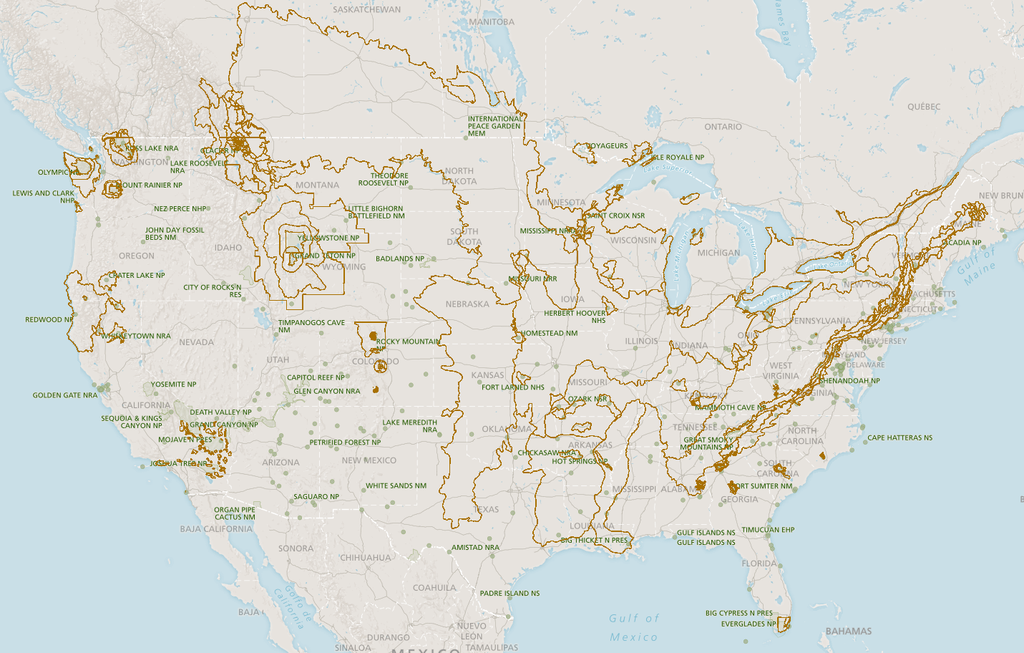

**Figure 2.** Spatial extent of CONUS-based custom AOAs (drawn in brown).

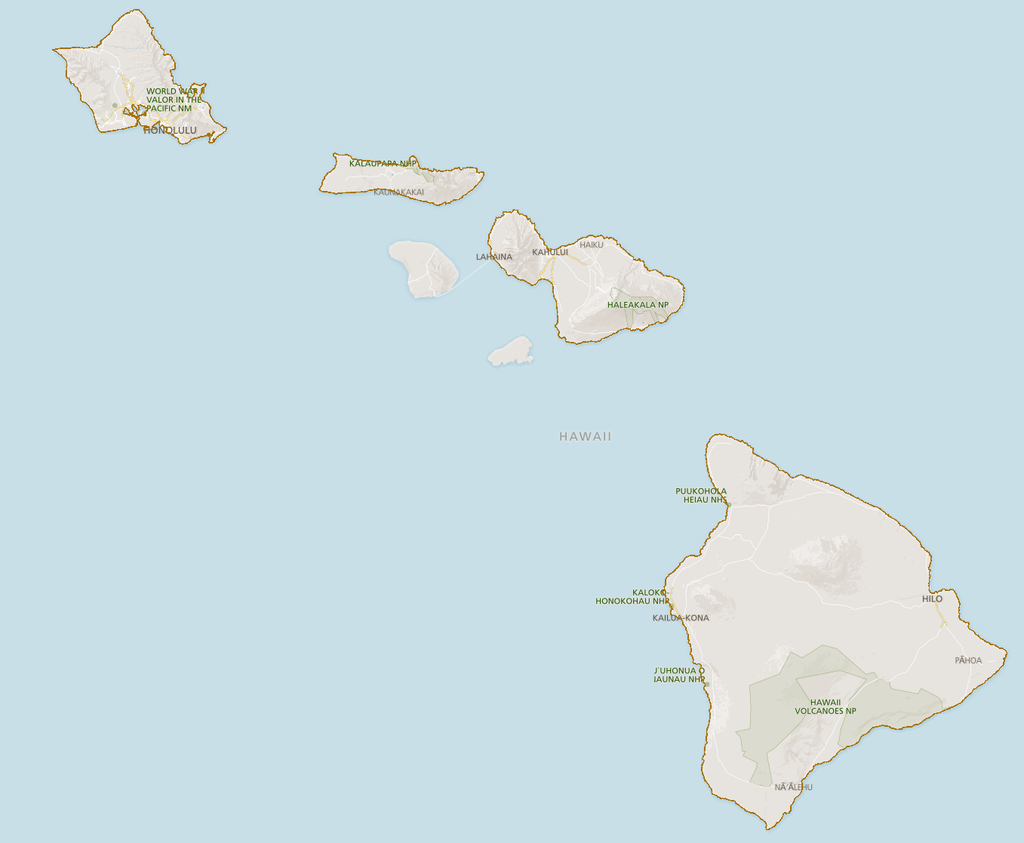

**Figure 3.** Spatial extent of Hawaii-based custom AOAs (drawn in brown).

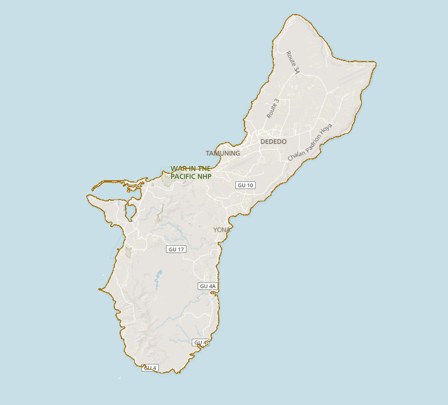

**Figure 4.** Spatial extent of Guam-based custom AOAs (drawn in brown).

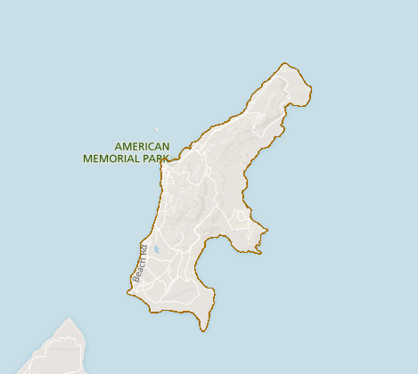

**Figure 5**. Spatial extent of CNMI-based custom AOAs (drawn in brown).

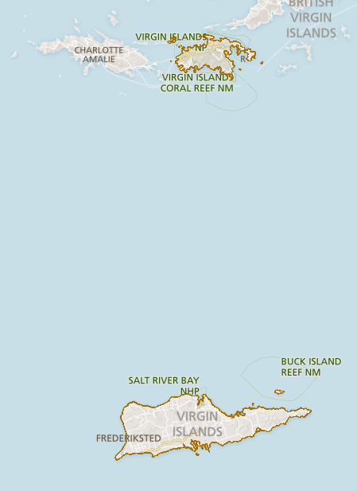

**Figure 6.** Spatial extent of U.S. Virgin Islands-based custom AOAs (drawn in brown).

# 8 Appendix B. All Added, Changed, or Removed Custom AOAs

**Table 7.** Full list of all added, changed, or removed Custom AOAs when compared to the preceding dataset.

| **Network** | **Custom AOA** | **Full Name** | **Change Reason from Preceding Version** | **IMD Create Date** |
| --- | --- | --- | --- | --- |
| MEDN | MEDN_CABR_PLECA_AOA_Area | Point Loma Ecological Conservation Area | Added Feature (A) | 9-20-2018 |
| MEDN | MEDN_SAMO_EcoMgmtZone_AOA_Area | Ecological Management Zone | Added Feature (A) | 9-20-2018 |

# 9 Appendix C. Python Code to Create Landscape Dynamics Custom AOAs

The following script will convert all custom AOAs for use. This script is only applicable to the datasets cited in this report.

```
import arcpy

import os, time

arcpy.env.overwriteOutput = 1

arcpy.env.workspace = r'' \# same as gdbToBeUpdated

gdbToBeUpdated = r'' \# full local path to output gdb,
“IMD_BND_ESProtocol_Custom_AOA.gdb”

pyToBeUpdated =
["IMD_BND_ESProtocol_Custom_albers_py","IMD_BND_ESProtocol_Custom_wgs_py"]

DomainGDB = r'' \# GDB of domain tables, (NPS IMD 2018c)

DOM_Change = 'DOM_ChangeReasonFromPrecedingVersion_NPSIMD2019'

DOM_DataCert = 'DOM_DataCertificationLevel_NPSIMD2019'

DOM_FeatAlt = 'DOM_FeatureAlteration_NPSIMD2019'

DOM_FeatLife = 'DOM_FeatureLifecycle_NPSIMD2019'

DOM_UnitCodeAlt = 'DOM_UnitCodeAlteration_NPSIMD2019'

DOM_NETREG = "DOM_NETWORKS_REGIONS_NPSIMD2019"

ConusSpatialRef = arcpy.SpatialReference(102039)

AKSpatialRef = arcpy.SpatialReference(3338)

HawaiiSpatialRef = arcpy.SpatialReference(26905)

PacificSaipanSpatialRef = arcpy.SpatialReference(32655)

PacificSamoaSpatialRef = arcpy.SpatialReference(2195)

USVISpatialRef = arcpy.SpatialReference(102039)

```

[output cut: 891 more lines]

```
for ds in datasets:

for fc in arcpy.ListFeatureClasses(feature_dataset=ds):

path = os.path.join(gdbToBeUpdated,ds,fc)

arcpy.AddMessage(fc)

arcpy.CreateFeatureclass_management(os.path.join(gdbToBeUpdated,ds),fc+"_new","POLYGON",[template])

arcpy.Append_management(path,os.path.join(gdbToBeUpdated,ds,fc+"_new"),"NO_TEST")

arcpy.Delete_management(path)

arcpy.Rename_management(os.path.join(gdbToBeUpdated,ds,fc+"_new"),path)
```

# 10 Appendix D. Session and Version Information

```
Windows 10 Enterprise
Version 1803
Installed on 9/26/2018
OS build 17134.984
```

```
ArcMap/Catalog 10.6.1.9270
Python 2.7.3 64-bit
```

```
Pyscripter 3.6.0.0 x64
```

The National Park Service, Natural Resource Stewardship and Science office in Fort Collins, Colorado, publishes a range of reports that address natural resource topics. These reports are of interest and applicability to a broad audience in the National Park Service and others in natural resource management, including scientists, conservation and environmental constituencies, and the public.

The Natural Resource Data Series is intended for the timely release of basic data sets and data summaries. Care has been taken to assure accuracy of raw data values, but a thorough analysis and interpretation of the data has not been completed. Consequently, the initial analyses of data in this report are provisional and subject to change.

All manuscripts in the series receive the appropriate level of peer review to ensure that the information is scientifically credible, technically accurate, appropriately written for the intended audience, and designed and published in a professional manner.

The creation of data sets documented in this report followed peer reviewed methods described or referenced herein. Resultant data sets were reviewed to ensure accuracy, completeness, and consistency with documented data quality standards, as well as for usability and reproducibility.

Views, statements, findings, conclusions, recommendations, and data in this report do not necessarily reflect views and policies of the National Park Service, U.S. Department of the Interior. Mention of trade names or commercial products does not constitute endorsement or recommendation for use by the U.S. Government.

This report is available in digital format from the [National Park Service Data Store](https://irma.nps.gov/datastore/). To receive this report in a format that is optimized to be accessible using screen readers for the visually or cognitively impaired, please email irma@nps.gov.